# KD Practicum 6.1

## Classification Problems I.

Classification problems are solved by generalization of regression methods. Similarly though, there are common steps also utilized by regression scenarios and in this exercise, you will explore them in conjunction to fitting a logistic function onto the data. The basic steps that you will go through include tasks concerning:

- Data pre-processing.
- Exploring your data. For any classification method to work correctly, there must be a clear water between observations of different classes.
- Creating a logistic model using built-in functions such as the `glm()` function from the stats package. The logistic regression model will output the probabilities of each observations being classified positively. For example, the default probability for balance of 1000$ translates into the 0,5% chance of a client defaulting for the given balance value.
- Testing several probability cut-offs before deciding on the best decision rule.
- Generalizing your findings for unseen data.
- Interpreting your findings and refine your model if necessary.

### Project setup and hypothesis definition

We will use the logistic function to predict the default state of a client by regressing onto his account balance. We assume that there might be a relationship between higher balances and the chance of default, perhaps having more money lures one into dangerous spending habits. Logistic regression tells us if that is true, such that we can draw a line that will separate the two classes of clients based on their $ balances.

If no clear distinction can be made, then it will be imperative to set a line that can minimize either

- the number of missclassified defaulters because every defaulter costs the bank its money (that will be never repaid), or,
- the missclassification rate of both classes; assuming that not only false negative defaulters cost the bank its money, but also the bank’s fame is negatively impacted by false positive clients who won’t default, but their loans are being rejected.

At any rate, it’s always good to test few cut-off values before trying to interpret the model. This exercise is about setting up other-than-default cut-off value for the decision rule. You mostly need the logistic function from the **stats** package. Other functionalities implemented by **tidymodels**, **tidyverse** and **magrittr.** **broom** and **caret** packages are optional, but highly recommended.

### Credit card dataset

We will use a simulated data set containing information on ten thousand customers, which is available for downloading from the cloud.

- **Task 1:** Load data from `Default.csv` into R. Are they ready to be modeled? If not, transform them into suitable format.

  ```r
  #One-hot encoding
  data$default <- ifelse(data$default == "Yes",1,0) # One-hot encoding for default
  data$student <- ifelse(data$student == "Yes", 1,0) # One-hot encoding for student
  #Converting to binary variables to factors
  data %<>% mutate(default = as_factor(default))
  data %<>% mutate(student = as_factor(student))
  # Adding client IDs.
  data %<>% mutate(ID = 1:length(data$default))
  data %<>% select(ID, everything())
  ```

### Exploratory data analysis

- **Task 2:** Logistic regression works only if a modeled variable follows normal distribution and there is good separation of observations between classes (two in our case). Check if these conditions are fulfilled with EDA and/or basic plotting. Think about which statistical methods/functions are suitable to get this information. Research and retrieve any code needed.

  **Answer:** Separation of classes means that there can be a “line” drawn that splits data into two classes such that there are no miss-classified observations. This is not possible most of the time and our example is no exception. Let’s print histograms and Q-Q plots that can shed some light into how many. For this example, we will use basic R functions `hist()`, `line()`, `qqnorm()` and `qqline()`, but you are welcome to come with your own solution based on the ggplot2.

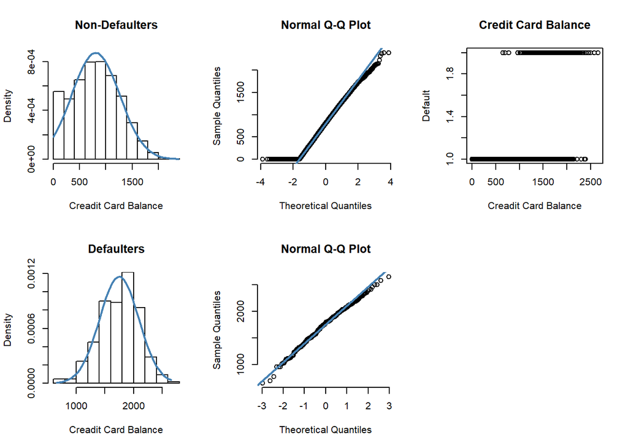

  It becomes clear that non-defaulters accumulate lower savings (mean: 804USD, standard error: 456USD) on their account compared to defaulters (mean: 1784USD , standard error: 341USD), and the distributions of both groups overlap. In addition, several other issues exist in our data with the following implications:
  - Fist, there are number of non-defaulters with 0 balance, meaning that they do not have any money left on their credit card account. This is a flaw that can be remedied by means of stratified sampling, should we model data as is.
  - Secondly, there are 9667 non-defaulters and 333 defaulters in the data set, making it unbalanced (although this is badly visible from the top right plot).
  - Third, no clear-line, or simple decision rule can be applied to correctly classify all observations and thus sacrifices have to be made.

### Model fitting

Logistic regression is available upon calling the generalized linear model function `glm()`. The `glm()` function is available from the **stats** package that is automatically loaded when you start R. The syntax for a logistic regression call can be outlined as follows:

```
logistic_regression_model_object <- glm(formula, data, family = binomial)
```

- **Task 3:** Fit a simple logistic regression function. It’s up to you the `glm()` function is called directly or via the parsnip interface. Capture the model as an object. Check what type/class the object is. Use `summary()`, `tidy()`, `str()` and `View()` and other functions to investigate its content. Think about what additional operations can you do with it. Fit a regression line with parsnip and compare the results. Are they the same? If not, have the same function/package been used for the fitting?

  ```r
  model <- glm(default ~ balance, data = data, family = binomial)
  tidy(model)
  ```

  ```
  ## # A tibble: 2 × 5
  ##   term         estimate std.error statistic   p.value
  ##   <chr>           <dbl>     <dbl>     <dbl>     <dbl>
  ## 1 (Intercept) -10.7      0.361        -29.5 3.62e-191
  ## 2 balance       0.00550  0.000220      25.0 1.98e-137
  ```

  **Answer:** `glm()` function returns a **list**, which is also an object of **lm** and **glm** type. This allows you subset it with rules you became familiar with in **Practicum 2.1** through **2.3**. To retrieve data from the object you can also use built-in functions from **Practicum 4.2**. Let’s investigate how this works with our model:

  ```r
  logR_model <- logistic_reg() %>% set_engine("glm")
  logR_form_fit <- logR_model %>% fit(default ~ balance, data = data)
  ```

  Parsnip uses the same `glm()` function for fitting so there are no differences in terms of the object’s content or the model’s parameters. However, remember that parsnip wraps the model object into another object containing metadata collected during the fitting. Hence, you have to go one level deeper to retrieve what information or data you want.

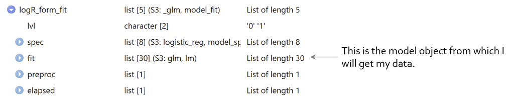

  ```r
  model$coefficients
  ```

  ```
  ##   (Intercept)       balance
  ## -10.651330614   0.005498917
  ```

  ```r
  logR_form_fit$fit$coefficients
  ```

  ```
  ##   (Intercept)       balance
  ## -10.651330614   0.005498917
  ```

### Setting up a decision rule

- **Task 4:** Logistic regression is a classification algorithm only in combination with a decision rule that makes binary decisions based on predicted probabilities of the outcome. By default, the decision boundary is set to 50%, or 0.50 for no real reason. But is 0.50 the right cut-off? Just because it is the default, does not mean it is necessary the best. In this exercise, you will examine how to test several cut-offs to the business problem.

  Compare these predictions to the ground truth by means of confusion matrices and model performance metrics taught through the course. Your goal is to come up with the confusion matrices like the ones plotted below:

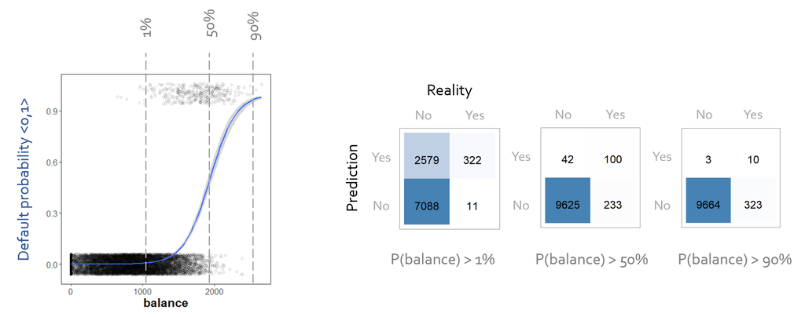

  Remember that the `glm()` function does not allow you to set custom thresholds, thus preventing you from making the predictions with a single function call.

  Instead, you have to find the way to leverage model information up to the point that confusion matrices can be generated. If you want to take this as a challenge, do not read the text below. It is possible that a package exists that does this for you and should you find one, please let me know.

  **Answer:** The tasks to perform are outlined on the following figure. **Task 3** tells you how to fit a logistic regression model onto the training data. Then, you have to extract the inferred probabilities for every observation and use them to re-classify the same observations using a pre-defined cut-off. The cut-off value is actually what makes the decision rule to tell whether a client will default or not after taking his/her account balance into account.

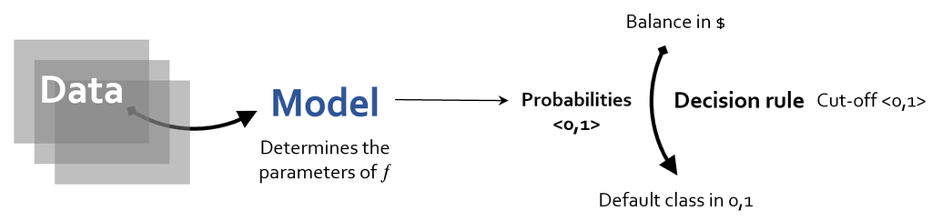

  To get to that point, just follow these steps:
  - First, use the existing model, or create a new one by fitting the logistic regression function onto data. Capture the model object.
  - For each balance value from the model object, retrieve the corresponding probability of default. The object contains fitted values. But what are these? Probabilities? Odds? Log odds? Find out.
  - If fitted values are not probabilities, find the way to convert them into probabilities. Since you are dealing with an S3 object, there must be a slew of helper functions to manipulate the encapsulated data. There are 10 000 records used for model training, so you are expected to land with 10 000 matched probabilities. One for each record.

  - At the end of this pipeline, you will create confusion matrix to compare the ground truth to your predictions. Ground truth data are accessible through `data$default` , which is a vector of factors with two levels: 0 for not-default and 1 for default.
  - Hence, you need to come up with an equivalent vector of ones and zeros that are assigned from modeled probabilities. For example, for cut-off of 1%, the client will be treated as defaulter if the estimated probability of default is higher than 0.01 (and hence one-hot encoded as 1).

    ```r
    glm.prediction <- rep(0, length(model.probabilities)) # create dummy output
    glm.prediction[model.probabilities > .01] = 1 # one-hot encoding with given probability threshold. This is the application of your decision rule.
    ```

  - You can use `table()` to generate the confusion matrix from these two vectors. As this is very dirty solution that does not come up with model performance metrics, you will use the `confusionMatrix()` function from the **caret** package. At the end of this quest you should see something like this:

    ```r
    # library(caret)
    confusionMatrix(as_factor(glm.prediction), as_factor(data$default), positive = "1")
    ```

    ```
    ## Confusion Matrix and Statistics
    ##
    ##           Reference
    ## Prediction    0    1
    ##          0 7088   11
    ##          1 2579  322
    ##
    ##                Accuracy : 0.741
    ##                  95% CI : (0.7323, 0.7496)
    ##     No Information Rate : 0.9667
    ##     P-Value [Acc > NIR] : 1
    ##
    ##                   Kappa : 0.1482
    ##
    ##  Mcnemar's Test P-Value : <2e-16
    ##
    ##             Sensitivity : 0.9670
    ##             Specificity : 0.7332
    ##          Pos Pred Value : 0.1110
    ##          Neg Pred Value : 0.9985
    ##              Prevalence : 0.0333
    ##          Detection Rate : 0.0322
    ##    Detection Prevalence : 0.2901
    ##       Balanced Accuracy : 0.8501
    ##
    ##        'Positive' Class : 1
    ##
    ```

### Classifying new observations

The most useful output of a logistic regression model are probabilities, which are accessible either by subsetting the model object (`model$fitted.values`), or by using the `fitted()` function. They can be extracted and used for many cool applications such as:

- converting new $ values of balance into probabilities and then to classes, thus making predictions for data not used for model training. Say, we receive a new client with balance of 5000$. Will he likely default? If not, how far is he from the decision boundary?
- reporting probabilities as values of balance. This is extremely useful for model interpretation. This allows to do informed decisions about loan policies by people who do not understand anything about models and not much about probabilities either. Just say to them: “well, if you client has surplus of 2000$ on his/her bank account, then he/she will most likely default”.

Generally, converting probabilities into classes is not a straightforward process, but rather an iterative one. **Practicum 7** will have more to say on this topic, but for now let’s just say that you need a decision rule and a cut-off to convert the probabilities into the classes. This is outlined on an updated Figure from **Task 4**:

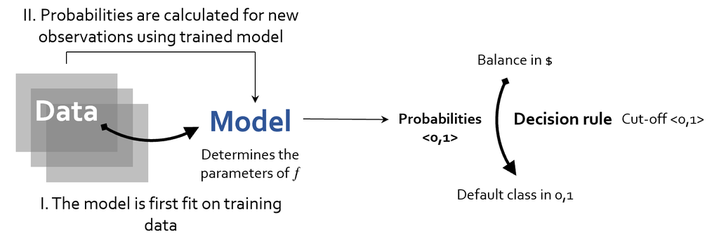

To get the probabilities, you can use the `predict()` function to which the name of the glm model object is provided, followed by numeric vector containing new observations.

```
new_data_probabilities <- predict(lm_model, new_data_input, type="response")
```

The `predict()` function will calculate probabilities for the new data only. You can use the same principles for converting these probabilities to respective classes that we have shown in **Task 4**.

### Working with model probabilities

- **Task 5:** Now, you should try to predict the probabilities of balance for values of 1000, 1300, 1700, 2000, 3000. These are new clients that your bank wants you to access.

  ```r
  newData <- predict(model,
                     newdata = tibble(balance=c(1000, 1300, 1700, 2000, 3000)),
                     type="response")
  names(newData) <- c(1000, 1300, 1700, 2000, 3000)
  newData
  ```

  ```
  ##        1000        1300        1700        2000        3000
  ## 0.005752145 0.029234410 0.213631687 0.585769370 0.997115227
  ```

  **Answer:** We use the `predict()` function. Note that `predict()` has several dedicated versions that are selected upon receiving type of the model. Here, you run the `predict.glm()` function in the background, which is parametrized by **type**. The default **type** is on the scale of the linear predictors; the alternative `"response"` is on the scale of the response variable. Thus for a default binomial model the default predictions are of log-odds (probabilities on logit scale) and `type = "response"` gives the predicted probabilities.
- **Task 6:** And then convert the probabilities of default into classes using threshold of 0.6. How many of these clients will 0.6 decision boundary put into default?

  ```r
  classPrediction <- rep(0, length(newData))
  classPrediction[newData > .6] = 1
  names(classPrediction) <- c(1000, 1300, 1700, 2000, 3000)
  classPrediction
  ```

  ```
  ## 1000 1300 1700 2000 3000
  ##    0    0    0    0    1
  ```